# How does fuseMLR work?

Cesaire Fouodo

2024-12-05

## A - Introduction

The R package **fuseMLR** offers a framework for late integrative predictive modeling using multi-omics data. This vignette serves as a user guide to use the package effectively. Three key functionalities are provided: variable selection for modality-specific data, late integrative multi-omics training, and predictions for testing multi-omics datasets.

## B - Data

```r
library(fuseMLR)
```

```r
data("multi_omics")
# This list contains two lists of data: training and test.
# Each sublist contains three omics data as described above.
str(object = multi_omics, max.level = 2L)
```

```
#> List of 2
#>  $ training:List of 4
#>   ..$ geneexpr   :'data.frame':  50 obs. of  132 variables:
#>   ..$ proteinexpr:'data.frame':  50 obs. of  161 variables:
#>   ..$ methylation:'data.frame':  50 obs. of  368 variables:
#>   ..$ target     :'data.frame':  70 obs. of  2 variables:
#>  $ testing :List of 4
#>   ..$ geneexpr   :'data.frame':  20 obs. of  132 variables:
#>   ..$ proteinexpr:'data.frame':  20 obs. of  161 variables:
#>   ..$ methylation:'data.frame':  20 obs. of  368 variables:
#>   ..$ target     :'data.frame':  30 obs. of  2 variables:
```

## C - Training

The training process is handled in **fuseMLR** by a class called **Training**. We will use `training` to refer to an instance from this class. Function `createTraining` is available to create an empty (without layers) `training`.

### C.1 - Creating a training

```r
training <- createTraining(id = "training",
                           ind_col = "IDS",
                           target = "disease",
                           target_df = multi_omics$training$target,
                           verbose = TRUE)
print(training)
```

```
#> Training        : training
#> Problem type    : classification
#> Status          : Not trained
#> Number of layers: 0
#> Layers trained  : 0
```

A `training` contains modality-specific training layers (instances of the **TrainLayer** class) and a meta-layer (instance of the **TrainMetaLayer** class). The modality-specific training layers encapsulate training data modalities, variable selection functions and learners (i.e. `R` functions implementing statistical predicting methods). The meta-layer encapsulates the meta-learner.

Three main functions are necessary to create the `training`: `createTraining()`, `createTrainLayer()` and `createTrainMetaLayer()`. `createTraining()` creates an empty `training`, on which modalitity-specific training layers are added using the function `createTrainLayer()`. Function `createTrainMetaLayer()` is used to add meta-layer to `training`.

The following code adds a gene expression, a protein abundance, and a methylation layer to `training`. For illustration purpose we use the same variable selection method `Boruta` and the same learner (`ranger`) for all layers. These functions fulfill `fuseMLR` requirements in terms of arguments and outputs (see `createTrainLayer` documentation for details). We expect the variable selection function to accept two arguments: `x` (the predictor design matrix) and `y` (the response vector). The function must return a vector of selected variables. Methods that do not follow this format – such as Vita (via `ranger`) or Lasso (via `glmnet`) – require additional wrapping or a custom function to extract the selected variables, for example, based on a significance threshold. For learners, the arguments `x` and `y` are mandatory as well, and the resulting model must support the generic `predict` function. Predictions should be returned either as a vector or a list with a `predictions` field containing the predicted values (also a vector). If the function does not meet the required input and output criteria, users should follow the steps in E-Interface and wrapping and Wrapping to create an interface or wrap their function for use with fuseMLR.

```r
# Create gene expression layer.
createTrainLayer(training = training,
                 train_layer_id = "geneexpr",
                 train_data = multi_omics$training$geneexpr,
                 varsel_package = "Boruta",
                 varsel_fct = "Boruta",
                 varsel_param = list(num.trees = 1000L,
                                     mtry = 3L,
                                     probability = TRUE),
                 lrner_package = "ranger",
                 lrn_fct = "ranger",
                 param_train_list = list(probability = TRUE,
                                         mtry = 1L),
                 param_pred_list = list(),
                 na_action = "na.keep")
```

```
#> Training        : training
#> Problem type    : classification
#> Status          : Not trained
#> Number of layers: 1
#> Layers trained  : 0
#> p               : 131
#> n               :  50
```

```r
# Create gene protein abundance layer
createTrainLayer(training = training,
                 train_layer_id = "proteinexpr",
                 train_data = multi_omics$training$proteinexpr,
                 varsel_package = "Boruta",
                 varsel_fct = "Boruta",
                 varsel_param = list(num.trees = 1000L,
                                     mtry = 3L,
                                     probability = TRUE),
                 lrner_package = "ranger",
                 lrn_fct = "ranger",
                 param_train_list = list(probability = TRUE,
                                         mtry = 1L),
                 param_pred_list = list(type = "response"),
                 na_action = "na.keep")
```

```
#> Training        : training
#> Problem type    : classification
#> Status          : Not trained
#> Number of layers: 2
#> Layers trained  : 0
#> p               : 131 | 160
#> n               :  50 |  50
```

```r
# Create methylation layer
createTrainLayer(training = training,
                 train_layer_id = "methylation",
                 train_data = multi_omics$training$methylation,
                 varsel_package = "Boruta",
                 varsel_fct = "Boruta",
                 varsel_param = list(num.trees = 1000L,
                                     mtry = 3L,
                                     probability = TRUE),
                 lrner_package = "ranger",
                 lrn_fct = "ranger",
                 param_train_list = list(probability = TRUE,
                                         mtry = 1L),
                 param_pred_list = list(),
                 na_action = "na.keep")
```

```
#> Training        : training
#> Problem type    : classification
#> Status          : Not trained
#> Number of layers: 3
#> Layers trained  : 0
#> p               : 131 | 160 | 367
#> n               :  50 |  50 |  50
```

Also add a meta-layer. We use the weighted mean (internal function to `fuseMLR`) as meta-learner. Similarly learners, a meta-learner should allow at least the arguments `x` and `y` to pass the design matrix of predictors and should return a model that allow the call of the generic function `predict` to make predictions for a new dataset (see documentation of `createTrainMetaLayer` for details). If these criteria are not fulfill the explaination in E-Interface and wrapping can be used to map the `x` and `y` to the original argument names or to wrap the original function. We also provide information about possible meta-learner can be used in Appendix.

```r
# Create meta layer with imputation of missing values.
createTrainMetaLayer(training = training,
                     meta_layer_id = "meta_layer",
                     lrner_package = NULL,
                     lrn_fct = "weightedMeanLearner",
                     param_train_list = list(),
                     param_pred_list = list(),
                     na_action = "na.impute")
```

```
#> Training        : training
#> Problem type    : classification
#> Status          : Not trained
#> Number of layers: 4
#> Layers trained  : 0
#> p               : 131 | 160 | 367
#> n               :  50 |  50 |  50
```

```r
print(training)
```

```
#> Training        : training
#> Problem type    : classification
#> Status          : Not trained
#> Number of layers: 4
#> Layers trained  : 0
#> p               : 131 | 160 | 367
#> n               :  50 |  50 |  50
```

Function `upsetplot()` is available to generate an upset of the training data, i.e. an overview how patients overlap across layers.

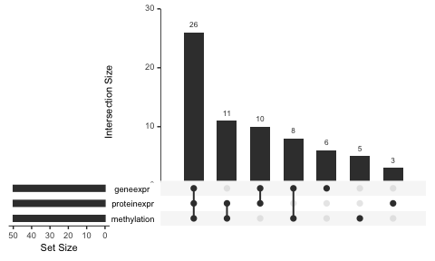

```r
upsetplot(object = training, order.by = "freq")
```

### C.2 - Variable selection

Function `varSelection()` performs modality-specific variable selection. So, a user can opt to conduct variable selection separately without training.

```r
# Variable selection
set.seed(5467)
var_sel_res <- varSelection(training = training)
```

```
#> Variable selection on layer geneexpr started.
#> Variable selection on layer geneexpr done.
#> Variable selection on layer proteinexpr started.
#> Variable selection on layer proteinexpr done.
#> Variable selection on layer methylation started.
#> Variable selection on layer methylation done.
```

```r
print(var_sel_res)
```

```
#>          Layer   variable
#> 1     geneexpr       ASNS
#> 2     geneexpr        ATM
#> 3     geneexpr       BRAF
#> 4     geneexpr       DVL3
#> 5     geneexpr      FOXM1
#> 6     geneexpr     MAP2K1
#> 7     geneexpr     MAPK14
#> 8     geneexpr        NF2
#> 9     geneexpr     NOTCH1
#> 10    geneexpr       PCNA
#> 11    geneexpr      PEA15
#> 12    geneexpr      PRDX1
#> 13    geneexpr      PRKCD
#> 14    geneexpr      RBM15
```

[output cut: 41 more lines]

For each layer, the variable selection results show the chosen variables.

### C.2 - Train

We use the function `fusemlr()` to train our models using the subset of selected variables. Here we set `use_var_sel = TRUE` to previously perform variable selection before model training.

```r
set.seed(5462)
fusemlr(training = training,
        use_var_sel = TRUE)
```

```
#> Creating fold predictions.
#> ================================================================================
#> Training on layer geneexpr started.
#> Training on layer geneexpr done.
#> Training on layer proteinexpr started.
#> Training on layer proteinexpr done.
#> Training on layer methylation started.
#> Training on layer methylation done.
#> Training        : training
#> Problem type    : classification
#> Status          : Trained
#> Number of layers: 4
#> Layers trained  : 4
#> Var. sel. used  : Yes
#> p               : 131 | 160 | 367 |  3
#> n               :  50 |  50 |  50 | 69
```

```r
print(training)
```

```
#> Training        : training
#> Problem type    : classification
#> Status          : Trained
#> Number of layers: 4
#> Layers trained  : 4
#> Var. sel. used  : Yes
#> p               : 131 | 160 | 367 |  3
#> n               :  50 |  50 |  50 | 69
```

We can also display a summary of `training` to see more details on layer levels. Information about the training data modality, the variable selection method and the learner stored at each layer will be displayed.

```r
summary(training)
```

```
#> Training training
#> ----------------
#> Training        : training
#> Problem type    : classification
#> Status          : Trained
#> Number of layers: 4
#> Layers trained  : 4
#> Var. sel. used  : Yes
#> p               : 131 | 160 | 367 |  3
#> n               :  50 |  50 |  50 | 69
#> ----------------
#>
#>    Layer geneexpr
#>    ----------------
#>    TrainLayer            : geneexpr
#>    Status                : Trained
#>    Nb. of objects stored : 4
#>    ----------------
#>    Object(s) on layer geneexpr
#>
#>       ----------------
#>       TrainData : geneexpr_data
#>       Layer      : geneexpr
#>       Ind. id.   : IDS
#>       Target     : disease
#>       n          : 50
#>       Missing    : 0
#>       p          : 133
#>       ----------------
#>
#>       ----------------
#>       VarSel           : geneexpr_varsel
#>       TrainLayer       : geneexpr
#>       Package          : Boruta
#>       Function         : Boruta
#>       ----------------
#>
#>       ----------------
#>       Learner          : geneexpr_lrner
#>       TrainLayer       : geneexpr
```

[output cut: 90 more lines]

```
#>       Target     : disease
#>       n          : 69
#>       Missing    : 0
#>       p          : 5
#>       ----------------
#>
#>
#> Training        : training
#> Problem type    : classification
#> Status          : Trained
#> Number of layers: 4
#> Layers trained  : 4
#> Var. sel. used  : Yes
#> p               : 131 | 160 | 367 |  3
#> n               :  50 |  50 |  50 | 69
```

We use `extractModel()` to retrieve the list of stored models and `extractData()` to retrieve training data.

```r
models_list <- extractModel(training = training)
print(str(object = models_list, max.level = 1L))
```

```
#> List of 4
#>  $ geneexpr   :List of 14
#>  $ proteinexpr:List of 14
#>  $ methylation:List of 14
#>  $ meta_layer : 'weightedMeanLearner' Named num [1:3] 0.268 0.27 0.462
#>   ..- attr(*, "names")= chr [1:3] "geneexpr" "proteinexpr" "methylation"
#> NULL
```

Three random forests and one weighted meta-model trained on each layer are returned.

```r
data_list <- extractData(object = training)
str(object = data_list, max.level = 1)
```

```
#> List of 4
#>  $ geneexpr   :'data.frame': 50 obs. of  133 variables:
#>  $ proteinexpr:'data.frame': 50 obs. of  162 variables:
#>  $ methylation:'data.frame': 50 obs. of  369 variables:
#>  $ meta_layer :'data.frame': 69 obs. of  5 variables:
```

The three simulated training modalities and the meta-data are returned.

## D - Predicting

In this section, we create a `testing` instance (from the *Testing* class) and make predictions for new data. This is done analogously to `training`. Only the testing data modalities are required. Relevant functions are `createTesting()` and `createTestLayer()`.

```r
# Create testing for predictions
testing <- createTesting(id = "testing",
                         ind_col = "IDS")
```

```r
# Create gene expression layer
createTestLayer(testing = testing,
                test_layer_id = "geneexpr",
                test_data = multi_omics$testing$geneexpr)
```

```
#> Testing         : testing
#> Number of layers: 1
#> p               : 131
#> n               :  20
```

```r
# Create gene protein abundance layer
createTestLayer(testing = testing,
                test_layer_id = "proteinexpr",
                test_data = multi_omics$testing$proteinexpr)
```

```
#> Testing         : testing
#> Number of layers: 2
#> p               : 131 | 160
#> n               :  20 |  20
```

```r
# Create methylation layer
createTestLayer(testing = testing,
                test_layer_id = "methylation",
                test_data = multi_omics$testing$methylation)
```

```
#> Testing         : testing
#> Number of layers: 3
#> p               : 131 | 160 | 367
#> n               :  20 |  20 |  20
```

A summary of `testing`.

```r
summary(testing)
```

```
#> Testing testing
#> ----------------
#> Testing         : testing
#> Number of layers: 3
#> p               : 131 | 160 | 367
#> n               :  20 |  20 |  20
#> ----------------
#>
#> Class     : TestData
#> name      : geneexpr_data
#> ind. id.  : IDS
#> n         : 20
#> p         : 132
#>
#>
#> Class     : TestData
#> name      : proteinexpr_data
#> ind. id.  : IDS
#> n         : 20
#> p         : 161
#>
#>
#> Class     : TestData
#> name      : methylation_data
#> ind. id.  : IDS
#> n         : 20
#> p         : 368
```

A look on testing data.

```r
data_list <- extractData(object = testing)
str(object = data_list, max.level = 1)
```

```
#> List of 3
#>  $ geneexpr   :'data.frame': 20 obs. of  132 variables:
#>  $ proteinexpr:'data.frame': 20 obs. of  161 variables:
#>  $ methylation:'data.frame': 20 obs. of  368 variables:
```

We can also generate an upset plot to visualize patient overlap across testing layers.

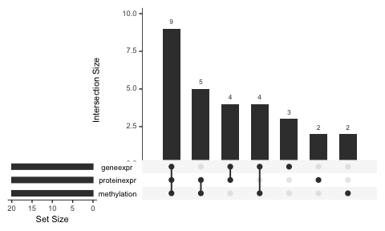

```r
upsetplot(object = testing, order.by = "freq")
```

Function `predict()` is available for predicting.

```r
predictions <- predict(object = training, testing = testing)
print(predictions)
```

```
#> $predicting
#> Predicting   : testing
#> Nb. layers   : 4
#>
#> $predicted_values
#>               IDS  geneexpr proteinexpr methylation meta_layer
#> 1  participant100 0.3788944   0.6326063   0.1251825  0.3301829
#> 2   participant20 0.1571294   0.1571294   0.1571294  0.1571294
#> 3   participant24 0.7400333   0.6601421   0.6843302  0.6927208
#> 4   participant25 0.3868008   0.3868008   0.3868008  0.3868008
#> 5   participant27 0.3497389   0.3659972   0.3822556  0.3691538
#> 6   participant28 0.6292540   0.1459032   0.3875786  0.3870573
#> 7    participant3 0.6919667   0.8694921   0.7807294  0.7809208
#> 8   participant32 0.1178167   0.4782968   0.2063500  0.2560725
#> 9   participant34 0.5838603   0.8426365   0.7550254  0.7328305
```

[output cut: 20 more lines]

Prediction performances for layer-specific levels, and on the meta layer are displayed.

- Brier score estimated.

```r
pred_values <- predictions$predicted_values
actual_pred <- merge(x = pred_values,
                     y = multi_omics$testing$target,
                     by = "IDS",
                     all.y = TRUE)
y <- as.numeric(actual_pred$disease == "1")

# On all patients
perf_bs <- sapply(X = actual_pred[ , 2L:5L], FUN = function (my_pred) {
  bs <- mean((y[complete.cases(my_pred)] - my_pred[complete.cases(my_pred)])^2)
  return(bs)
})
print(perf_bs)
```

```
#>    geneexpr proteinexpr methylation  meta_layer
#>   0.1284721   0.2635223   0.1129883   0.1411188
```

- AUC estimated.

```r
pred_values <- predictions$predicted_values
actual_pred <- merge(x = pred_values,
                     y = multi_omics$testing$target,
                     by = "IDS",
                     all.y = TRUE)
y <- actual_pred$disease

# On all patients
perf_auc <- sapply(X = actual_pred[ , 2L:5L], FUN = function (my_pred) {
  roc_obj <- pROC::roc(y[complete.cases(my_pred)], my_pred[complete.cases(my_pred)])
  auc_value <- pROC::auc(roc_obj)
  return(auc_value)
})
print(perf_auc)
```

```
#>    geneexpr proteinexpr methylation  meta_layer
#>   0.9904762   0.6119048   0.9761905   0.9666667
```

The weighted mean meta-learner is a good aggregation of the layer-specific learners.